# Wait... The NFL Honors Awards are Rigged?

While there are a ton of jokes and memes out there saying the NFL is rigged, it is important to not take jokes seriously. Obviously, the NFL is not rigged. Just imagine how challenging it would be for the NFL to influence the outcome of every play, of every game.

Despite this, is it possible that the NFL is pulling some strings? When it comes to awards, I would say definitely. While it's impossible to change the trajectory of every pass, tackle, touchdown, or field goal, it is very easy to influence the outcome of which players get the most recognition. At the end of the day, when there is no way to objectively say who's the best, a big corporation, like the NFL, is going to pick whoever will get them the most clicks on the internet for an award. My visualizations all tell this story by showing how vast outliers are often ignored. I don’t think there is any way this story could do harm, especially with the 2021 season being well over a year over. However, I have learned to never underestimate the anger and rage of sports fans. Then again, I am just using data to voice an opinion of one of my favorite sports leagues.

Now, let's take a look at the recipients of the annual MVP award.

```python
import pandas as pd
import matplotlib.pyplot as plt
import seaborn as sns
%matplotlib inline
```

```python
mvp  = pd.read_csv("mvps.csv")
pl = pd.read_csv("passingleaders.csv")
wr = pd.read_csv("wrs.csv")
df = pd.read_csv("defense.csv")
```

# MVPs

```python
mvp.head(8)
```

|  | Year | Lg | Pos | Player | Tm | Voting | Player-additional |
| --- | --- | --- | --- | --- | --- | --- | --- |
| 0 | 2021 | NFL | QB | Aaron Rodgers | Green Bay Packers | Voting | RodgAa00 |
| 1 | 2020 | NFL | QB | Aaron Rodgers | Green Bay Packers | Voting | RodgAa00 |
| 2 | 2019 | NFL | QB | Lamar Jackson | Baltimore Ravens | Voting | JackLa00 |
| 3 | 2018 | NFL | QB | Patrick Mahomes | Kansas City Chiefs | Voting | MahoPa00 |
| 4 | 2017 | NFL | QB | Tom Brady | New England Patriots | Voting | BradTo00 |
| 5 | 2016 | NFL | QB | Matt Ryan | Atlanta Falcons | Voting | RyanMa00 |
| 6 | 2015 | NFL | QB | Cam Newton | Carolina Panthers | Voting | NewtCa00 |
| 7 | 2014 | NFL | QB | Aaron Rodgers | Green Bay Packers | Voting | RodgAa00 |

Figure 1. Here, we see the last eight MVP winners, all of which are QBs (Quarterbacks). Let's take a look back even further in NFL history.

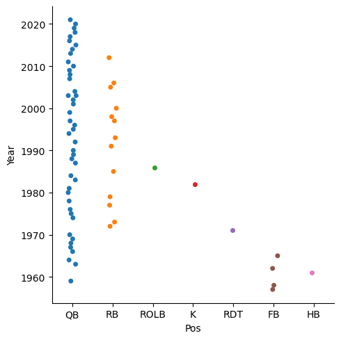

```python
mvp  = pd.read_csv("mvps.csv")
sns.catplot(data= mvp, x="Pos", y="Year" )
```

Figure 2. Here we have a catplot showing the distribution of positions to win the MVP Award.

Why is this?

Well for starters, the quarterback is by far the most recognizable position on the gridiron. If you ask a non-American to name football positions, chances are, the first thing they will say is the quarterback. The quarterback leads the offense. Quarterbacks are typically the only players on the field that can throw the ball. Perhaps this leadership role is what makes quarterbacks recognizable. However, quarterbacks being recognizable does not mean they are the most valuable or 'best' player on the field.

Usually, it's very hard to say someone is the best objectively, unless they are so far ahead of others in their field. This most recent year of the NFL had many quarterbacks that had a realistic shot at being deemed the most valuable QB. Quarterbacks are judged by wins, losses, completions, completion percentage, touchdowns, interceptions, and more. The most accurate way to judge a quarterback is by QBR (Quarterback Rating), a matrix designed to combine all of the previously stated stats into one number from zero to 158.3. Below, we have the top 10 quarterbacks of 2021 with their respective QBR's plotted.

# Quarterback Rating

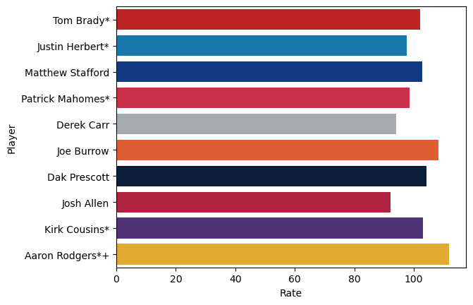

```python
palettePL = ["#D50A0A", "#0080C6", "#003594", "#E31837", "#A5ACAF",
           "#FB4F14", "#041E42", "#C60C30", "#4F2683", "#FFB612"]
sns.barplot(data= pl.head(10), x="Rate", y="Player", palette=palettePL )
```

Figure 3. The asterisk next to a player's name means they were selected to the Pro Bowl, the NFL's equivalent of an All-Star Game. The plus sign means the player was selected to First Team All-Pro, another form of recognition for the most elite players. Finally, for our more football savvy readers, the bars are colored based on each player's team in the 2021 season. These markers apply for all future graphs as well.

In 2021, Aaron Rodgers won MVP. On paper this seems fitting, but in reality, we are only comparing Rodgers against the 31 other starting NFL quarterbacks.

Since every NFL position is different, comparing one to another is difficult. Instead, we should look at how much better the best of a given position is when stacked up against others in the given position.

One of the biggest highlights of the 2021 season was Cooper Kupp. Kupp is a wide-receiver for the Los Angeles Rams. Not only did Kupp lead the league in receiving yards, but also receptions, and touchdowns.

# Receptions

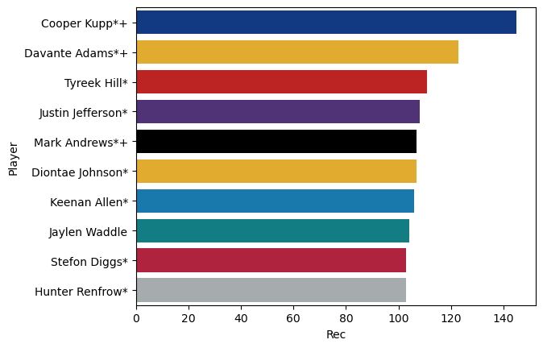

```python
wr = pd.read_csv("wrs.csv")
paletteWR = ["#003594","#FFB612","#D50A0A", "#4F2683", "#000000",
           "#FFB612", "#0080C6", "#008E97", "#C60C30", "#A5ACAF"]
sns.barplot(data= wr.head(10), x="Rec", y="Player", palette=paletteWR )
```

Figure 4. Receptions are the total amount of times a receiver catches the ball.

# Receiving Yards

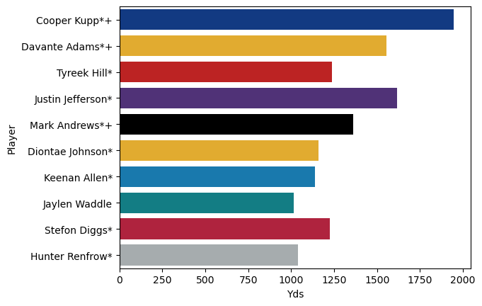

```python
paletteWR = ["#003594","#FFB612","#D50A0A", "#4F2683", "#000000",
           "#FFB612", "#0080C6", "#008E97", "#C60C30", "#A5ACAF"]
sns.barplot(data= wr.head(10), x="Yds", y="Player", palette=paletteWR )
```

Figure 5. Receiving Yards is the total amount of yards a receiver moves the ball via reception. This category contains both yards gained before and after the catch, leading up to when the receiver is tackled, pushed out of bounds, or scores a touchdown.

# Receiving Touchdowns

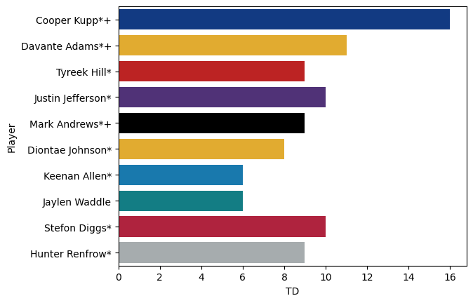

```python
paletteWR = ["#003594","#FFB612","#D50A0A", "#4F2683", "#000000",
           "#FFB612", "#0080C6", "#008E97", "#C60C30", "#A5ACAF"]
sns.barplot(data= wr.head(10), x="TD", y="Player", palette=paletteWR )
```

Figure 6. Receiving Touchdowns are the total amount of times a receiver moves the ball into the endzone via reception. They can either catch the ball in the endzone or run into the endzone with the ball in hand.

In each one of these categories, Kupp dismantled the competition. Breaking records left and right. Kupp became the first receiver since 2005 to win the triple crown (leading in receptions, yards, and touchdowns). On top of that Kupp would compete against 95 other starting wide receivers, three times as many as what Rodgers competes against. Surely the NFL would recognize this and award Kupp the MVP right?

Wrong. Instead, the NFL is stubborn and refuses to give the MVP to any player other than quarterbacks. Even with the best statistical season ever for a wide receiver, Kupp is relegated to Offensive Player of the Year, an award that has become second place to the elusive MVP.

Let's take a look at the other side of the field. Maybe the offense was a fluke?

# Sacks

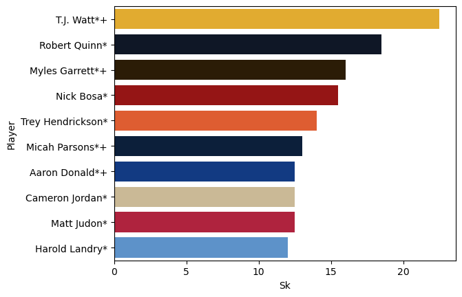

```python
df = pd.read_csv("defense.csv")
df.sort_values("Sk" , ascending = False)
paletteDF = ["#FFB612","#0B162A","#311D00", "#AA0000", "#FB4F14",
           "#041E42", "#003594", "#D3BC8D", "#C60C30", "#4B92DB"]
sns.barplot(data= df.sort_values("Sk" , ascending = False).head(10), x="Sk", y="Player", palette=paletteDF )
```

Figure 7. Sacks are the total amount of times a defensive player of ANY position tackles the opposing quarterback behind the line of scrimmage.

Defensive stats are often extremely hard to quantify, as the defense is reacting to whatever the offense is doing. However, sometimes there are impressive outliers. In the 2021 season, TJ Watt tied the all-time NFL record for most sacks in a single season. What is even more impressive about this is that Watt did this by playing 2 games less than his closest competition. Watt was awarded defensive player of the year, but tying an all-time record is far more impressive than beating 31 quarterbacks in QBR over one season.

Kupp and Watt's record-breaking seasons are anomalies, they happen once in a decade. Not only did Kupp and Watt beat the best of 2021, but they beat the thousands that have played before them. Still, the NFL would rather put their most recognizable quarterbacks on a higher pedestal than record breaking position player.

# Conclusion

Why does the NFL make questionable decisions when it comes to awards? Well, seeing how the NFL has exploded in popularity over the last few decades, I think it is fair to say the NFL knows how to manipulate its viewers. By distributing questionable awards, the NFL gets more people talking. This leads to more attention. The NFL does not care if their viewers are arguing as the league is still getting more attention. Generally, arguments are a huge buzz on social media, why not manufacture them?

In the end, I’m not saying you shouldn’t watch the NFL or other sports leagues. However, I think fans should learn to not worry about who wins the awards at the end of the season. Even though we have a massive amount of statistics at our disposal, the NFL Honors Awards are quite subjective when we listen to the “experts.”

# Production

I was surprised to see that Pro Football Reference had an option to convert their statistics to a .csv or excel file. The “Share and Export” drop down button provided for great ease in obtaining this data. In the many years I have known of and used Pro Football Reference, I never noticed this option. Transitioning this information to graphs was a little frustrating at first, but got much easier as I got into a rhythm. Due to most of these stats being player oriented, I used bar graphs often to sort this data. For the position distribution, I used a catplot, which I had no idea even existed until creating this project.

Unfortunately, I had some failed attempts in putting this story together. After completing my rough draft, I experimented with various types of plots. Scatter plots and line plots really didn’t do much in visualizing my story. I also tried using the .add function found on Seaborn’s website, but I couldn’t figure out how to work that. Instead, I looked for a work around.

Some of the most fun I had with this assignment was the customization of my visualizations. The palette feature at first seemed very limited, until I created my own palette. For each bar graph, I researched the hex values of each player’s team’s colors. Even though the other methods of visualization might not be the best for this data, it would still be fun to know what all of them do.

As I stated earlier, I find it hard to believe this story would cause any hard. I imagine the NFL itself would disagree and deny what I’m saying, but I don’t really care. My work here was heavily inspired by the YouTube channel, Secret Base, which specializes in telling stories through sports statistics.

# Sources

"AP NFL Most Valuable Player Winners." Pro Football Reference, https://www.pro-football-reference.com/awards/ap-nfl-mvp-award.htm.

"MLA Tables, Figures, and Examples." Purdue Online Writing Lab, https://owl.purdue.edu/owl/research_and_citation/mla_style/mla_formatting_and_style_guide/mla_tables_figures_and_examples.html.

"Secret Base." YouTube, https://www.youtube.com/@SecretBaseSBN.

"2021 NFL Defense." Pro Football Reference, https://www.pro-football-reference.com/years/2021/defense.htm.

"2021 NFL Passing." Pro Football Reference, https://www.pro-football-reference.com/years/2021/passing.htm.

"2021 NFL Receiving." Pro Football Reference, https://www.pro-football-reference.com/years/2021/receiving.htm.